# STA321 Week #6 Assignment: Simple Logistic Regression

Joshua

October 05, 2026

# 1 Introduction

The sinking of the *Titanic* in April 1912 is one of the most studied disasters in statistics because the passenger records contain a clear binary outcome, survived or died, along with demographic and ticket information. On the *Titanic*, lifeboat access depended on where passengers were on the ship, and ticket price was closely tied to cabin location and passenger class, survival was not completely random. Fare is therefore a reasonable single-number proxy for socioeconomic position and proximity to the lifeboats. This assignment studies the **association** between the fare a passenger paid and their probability of survival using a simple logistic regression model.

# 2 Data Source

The data set contains 891 passengers. It is available in the seaborn-data repository on GitHub:

https://github.com/mwaskom/seaborn-data/blob/master/titanic.csv

The variables used are:

1. **survived**: Binary response, 1 = survived, 0 = died
2. **pclass**: Ticket class (1 = upper, 2 = middle, 3 = lower), categorical
3. **sex**: Sex of the passenger, categorical
4. **embarked**: Port of embarkation (C = Cherbourg, Q = Queenstown, S = Southampton), categorical
5. **age**: Age in years, numerical
6. **sibsp**: Number of siblings/spouses aboard, numerical
7. **parch**: Number of parents/children aboard, numerical
8. **fare**: Fare paid, numerical

```r
titanic <- read.csv("https://raw.githubusercontent.com/Joshuaxav/STA321F26/main/titanic.csv")

names(titanic) <- tolower(names(titanic))  # safeguard in case column names are capitalized

n        <- nrow(titanic)
n.surv   <- sum(titanic$survived == 1)
n.died   <- sum(titanic$survived == 0)
n.age.na <- sum(is.na(titanic$age))
n.zero   <- sum(titanic$fare == 0)
head(titanic[, c("survived", "pclass", "sex", "age", "sibsp", "parch", "fare", "embarked")])
```

```
  survived pclass    sex age sibsp parch    fare embarked
1        0      3   male  22     1     0  7.2500        S
2        1      1 female  38     1     0 71.2833        C
3        1      3 female  26     0     0  7.9250        S
4        1      1 female  35     1     0 53.1000        S
5        0      3   male  35     0     0  8.0500        S
6        0      3   male  NA     0     0  8.4583        Q
```

Age has **177** missing values (19.9%). Since this model only uses fare, which is complete, no records need to be deleted, so I keep all **891** observations. Also, **15** passengers have a recorded fare of $0 (likely crew, guarantee staff, or fares not recorded). I kept them because they are valid observations.

# 3 Analytic Question

Is the fare a passenger paid associated with their odds of surviving the sinking? To answer this I will find how much the the odds of survival change as fare increases and how the *probability* of survival, and its rate of change, behave across the range of fares.

# 4 Exploratory Data Analysis

Since this is a simple logistic regression, only one predictor is in the model. First, I check the distribution of the predictor to make sure it is not extremely skewed.

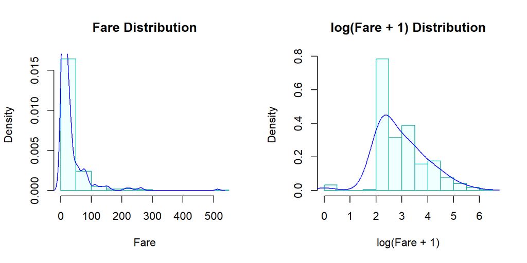

```r
par(mfrow = c(1, 2))
hist(titanic$fare, probability = TRUE, main = "Fare Distribution", xlab = "Fare",
     col = "azure1", border = "lightseagreen")
lines(density(titanic$fare, adjust = 2), col = "blue")

titanic$logfare <- log(titanic$fare + 1)   # +1 because some fares are 0
hist(titanic$logfare, probability = TRUE, main = "log(Fare + 1) Distribution", xlab = "log(Fare + 1)",
     col = "azure1", border = "lightseagreen")
lines(density(titanic$logfare, adjust = 2), col = "blue")
```

```r
par(mfrow = c(1, 1))
```

The histogram on the left shows that fare is **extremely right-skewed** (sample skewness = 4.78, median $14.45, mean $32.2, maximum $512.33). Most passengers paid small fares and a small number paid very large ones, and these high-leverage points can distort the fitted slope. Unlike a mildly skewed predictor, this one needs a transformation. After applying log(Fare + 1), the distribution on the right is much more symmetric (skewness = 0.39). I therefore use **log(Fare + 1)** as the predictor in the logistic regression model.

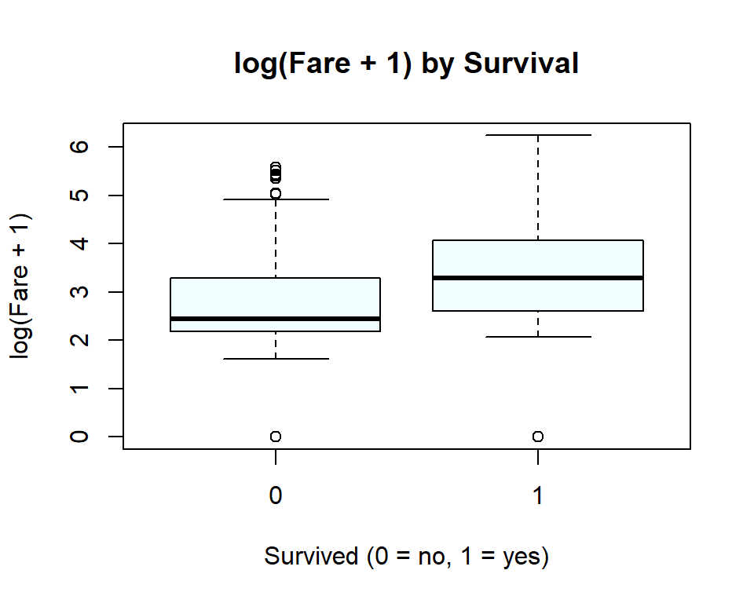

Figure 2: log(Fare + 1) by Survival Boxplot

```r
boxplot(logfare ~ survived, data = titanic, col = "azure1",
        xlab = "Survived (0 = no, 1 = yes)", ylab = "log(Fare + 1)",
        main = "log(Fare + 1) by Survival")
```

```r
# survival proportion within fare quintiles
titanic$fq <- cut(titanic$fare, breaks = quantile(titanic$fare, probs = seq(0, 1, .2)), include.lowest = TRUE)
quint <- data.frame(
  mean.fare     = tapply(titanic$fare, titanic$fq, mean),
  mean.logfare  = tapply(titanic$logfare, titanic$fq, mean),
  survival.rate = tapply(titanic$survived, titanic$fq, mean),
  n             = as.numeric(table(titanic$fq))
)
quint$emp.logit <- log(quint$survival.rate / (1 - quint$survival.rate))
pander(round(quint, 3), caption = "Survival rate by fare quintile")
```

Survival rate by fare quintile

|  | mean.fare | mean.logfare | survival.rate | n | emp.logit |
| --- | --- | --- | --- | --- | --- |
| **[0,7.85]** | 6.823 | 1.953 | 0.218 | 179 | -1.278 |
| **(7.85,10.5]** | 8.624 | 2.26 | 0.201 | 184 | -1.38 |
| **(10.5,21.7]** | 15.21 | 2.771 | 0.424 | 172 | -0.305 |
| **(21.7,39.7]** | 28.92 | 3.388 | 0.444 | 180 | -0.223 |
| **(39.7,512]** | 102.6 | 4.474 | 0.642 | 176 | 0.584 |

Based on the analysis, survivors tended to pay more. The median fare was **$26** for survivors and **$10.5** for non-survivors. The survival proportion rises from **21.8%** in the lowest fare quintile to **64.2%** in the highest.

The response variable, `survived`, is binary. Of the 891 passengers, 342 (38.4%) survived. This is a moderately balanced response, so class imbalance isn’t a concern for the modeling.

# 5 Building the Logistic Regression Model

The response is binary, so I model $Y_i \sim \text{Bernoulli}(p_i)$ with a logit link, where $p_i = P(\text{survived}_i = 1)$:

$$\text{logit}(p_i) =
\ln\left(\frac{p_i}{1-p_i}\right) = \beta_0 + \beta_1
\,\log(\text{Fare}_i + 1)$$

The logit link keeps the fitted probabilities inside (0, 1), which a linear probability model cannot guarantee. The parameters are estimated by maximum likelihood. Because `survived` is coded 0/1, `glm()` models the probability of survival (the event coded 1).

```r
s.logit <- glm(survived ~ logfare,
               family = binomial(link = "logit"),   # logit(p) = log(p/(1-p))
               data = titanic)
result <- summary(s.logit)
result
```

```
Call:
glm(formula = survived ~ logfare, family = binomial(link = "logit"),
    data = titanic)

Coefficients:
            Estimate Std. Error z value Pr(>|z|)
(Intercept) -2.81872    0.26471 -10.648   <2e-16 ***
logfare      0.77664    0.08348   9.303   <2e-16 ***
---
Signif. codes:  0 '***' 0.001 '**' 0.01 '*' 0.05 '.' 0.1 ' ' 1

(Dispersion parameter for binomial family taken to be 1)

    Null deviance: 1186.7  on 890  degrees of freedom
Residual deviance: 1085.0  on 889  degrees of freedom
AIC: 1089

Number of Fisher Scoring iterations: 4
```

The fitted model is

$$\text{logit}(\hat{p}) = -2.8187 + 0.7766
\times \log(\text{Fare} + 1)$$

The summary of the major statistics for the coefficients, including the 95% profile-likelihood confidence intervals is:

```r
model.coef.stats <- summary(s.logit)$coef          # output stats of coefficients
conf.ci <- confint(s.logit)                         # confidence intervals of betas
sum.stats <- cbind(model.coef.stats, conf.ci.95 = conf.ci)
pander(sum.stats, caption = "The summary stats of regression coefficients")
```

The summary stats of regression coefficients

|  | Estimate | Std. Error | z value | Pr(>\|z\|) | 2.5 % | 97.5 % |
| --- | --- | --- | --- | --- | --- | --- |
| **(Intercept)** | -2.819 | 0.2647 | -10.65 | 1.775e-26 | -3.348 | -2.31 |
| **logfare** | 0.7766 | 0.08348 | 9.303 | 1.361e-20 | 0.6161 | 0.9436 |

log(Fare + 1) shows a positive association with survival. The Wald test of $H_0: \beta_1 = 0$ is significant (*b* = 0.7766, *SE* = 0.0835, *z* = 9.3, *p* <.0001), and the 95% confidence interval for $\beta_1$, [0.6161, 0.9436], excludes zero.

Since he Wald test relies on a normal approximation, I also ran the likelihood ratio test comparing the fitted model to the intercept-only model: $G^2$ = 101.61 on 1 df, *p* <.0001. The two tests agree.

I exponentiate the coefficients to get the odds ratio. Because the predictor is on the log scale, a “one-unit” change is hard to picture, so I also report the odds ratio for a **doubling** of fare, which equals $e^{\beta_1 \ln 2} = 2^{\beta_1}$.

```r
odds.ratio <- exp(coef(s.logit))
out.stats <- cbind(model.coef.stats, odds.ratio = odds.ratio)
pander(out.stats, caption = "Summary Stats with Odds Ratios")
```

Summary Stats with Odds Ratios

|  | Estimate | Std. Error | z value | Pr(>\|z\|) | odds.ratio |
| --- | --- | --- | --- | --- | --- |
| **(Intercept)** | -2.819 | 0.2647 | -10.65 | 1.775e-26 | 0.05968 |
| **logfare** | 0.7766 | 0.08348 | 9.303 | 1.361e-20 | 2.174 |

```r
or1    <- exp(b1)                                 # per 1-unit increase in log(fare+1)
or2    <- 2^b1                                    # per doubling of (fare + 1)
ci.or2 <- exp(log(2) * conf.ci[2, ])              # profile-likelihood CI for doubling
odds0  <- exp(b0)
p0     <- plogis(b0)
```

Per one-unit increase in log(Fare + 1): the odds ratio is 2.174. A one-unit increase in log fare means multiplying (fare + 1) by *e* ≈ 2.72, so the odds of survival are multiplied by about 2.17.

Per doubling of fare : the odds ratio is **1.713**, 95% CI [1.533, 1.923]. Each time the fare doubles, the odds of survival increase by about **71%**. The interval excludes 1, consistent with the significant slope.

Intercept: $e^{\beta_0}$ = 0.06 is the odds of survival at Fare = $0 (log fare = 0), a probability of 0.056. Since there are 15 passengers at $0, this is not an extrapolation.

One caution: an odds ratio is not a relative risk. Survival is common here (38%), so “71% higher odds” overstates the change in the actual chance of surviving. The probability curve below shows the real change.

The global goodness-of-fit measures are in the table below.

```r
dev.resid   <- s.logit$deviance
dev.0.resid <- s.logit$null.deviance
aic <- s.logit$aic
goodness <- cbind(Deviance.residual = dev.resid, Null.Deviance.Residual = dev.0.resid, AIC = aic,
                  McFadden.R2 = mcf, Nagelkerke.R2 = nag)
pander(goodness)
```

| Deviance.residual | Null.Deviance.Residual | AIC | McFadden.R2 | Nagelkerke.R2 |
| --- | --- | --- | --- | --- |
| 1085 | 1187 | 1089 | 0.08563 | 0.1464 |

The null deviance is 1186.66 and the residual deviance is 1085.04. Both deviances are asymptotically $\chi^2$-distributed, and the drop between them is the likelihood ratio statistic reported above. The $R^2$ values (McFadden = 0.086, Nagelkerke = 0.146) are modest, so fare is a significant predictor but explains only part of who survived. That is expected, since sex, passenger class, and age are likely strong factors as well.

Its worth noting that the AIC and deviance are only interpretable when there are other candidate models on the same likelihood scale. Here, the raw-fare model is a legitimate comparison because it uses the same response and the same 891 observations:

```r
s.raw <- glm(survived ~ fare, family = binomial, data = titanic)
cmp <- data.frame(Model = c("Raw fare", "log(Fare + 1)"),
                  Residual.Deviance = c(s.raw$deviance, s.logit$deviance),
                  AIC = c(AIC(s.raw), AIC(s.logit)))
pander(cmp, caption = "Raw fare vs. log-transformed fare")
```

Raw fare vs. log-transformed fare

| Model | Residual.Deviance | AIC |
| --- | --- | --- |
| Raw fare | 1118 | 1122 |
| log(Fare + 1) | 1085 | 1089 |

The log model has a lower AIC (1089 vs. 1121.6), a difference of about 32.5, which is strong support for the transformation and agrees with the skewness seen in the EDA.

## 5.1 The success probability curve

Because of the logit link, the success probability is an S-shaped function of fare:

$$p(\text{fare}) = \frac{1}{1 +
e^{-(\beta_0 + \beta_1 \log(\text{fare} + 1))}}$$

The rate of change in probability with respect to fare (dollars) comes from the chain rule:

$$\frac{dp}{d\,\text{fare}} = \beta_1 \,
p\,(1-p) \cdot \frac{1}{\text{fare} + 1}$$

The $p(1-p)$ part makes the effect largest near $p = 0.5$, and the $1/(\text{fare}+1)$ part shrinks the effect of each dollar as fares get larger.

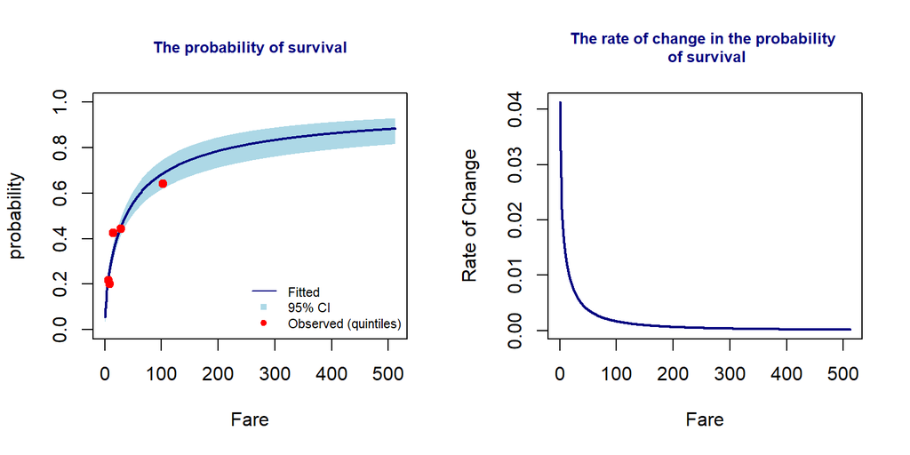

Figure 3: probability of survival and rate of change in the probability of survival graphs

```r
fare.x <- seq(0, max(titanic$fare), length.out = 500)
lx <- log(fare.x + 1)
beta.x <- b0 + b1 * lx
success.prob <- exp(beta.x) / (1 + exp(beta.x))
success.prob.rate <- b1 * exp(beta.x) / (1 + exp(beta.x))^2 / (fare.x + 1)

# 95% band built on the logit scale, then back-transformed
pr <- predict(s.logit, newdata = data.frame(logfare = lx), type = "link", se.fit = TRUE)
p.lo <- plogis(pr$fit - 1.96 * pr$se.fit)
p.hi <- plogis(pr$fit + 1.96 * pr$se.fit)

par(mfrow = c(1, 2))
plot(fare.x, success.prob, type = "n", ylim = c(0, 1),
     main = "The probability of survival", xlab = "Fare", ylab = "probability",
     col.main = "navy", cex.main = 0.8)
polygon(c(fare.x, rev(fare.x)), c(p.lo, rev(p.hi)), col = "lightblue", border = NA)
lines(fare.x, success.prob, lwd = 2, col = "navy")
points(quint$mean.fare, quint$survival.rate, pch = 19, col = "red")
legend("bottomright", legend = c("Fitted", "95% CI", "Observed (quintiles)"),
       lty = c(1, NA, NA), pch = c(NA, 15, 19), col = c("navy", "lightblue", "red"), bty = "n", cex = 0.7)

plot(fare.x, success.prob.rate, type = "l", lwd = 2, col = "navy",
     main = "The rate of change in the probability \n of survival",
     xlab = "Fare", ylab = "Rate of Change", col.main = "navy", cex.main = 0.8)
```

```r
par(mfrow = c(1, 1))
```

The left panel is the S curve showing how the probability of survival increases with fare. It rises steeply at low fares and flattens at high fares, since a doubling of a small fare is a tiny dollar change while a doubling of a large fare is a huge one. The fitted curve starts at 0.06 for a $0 fare, and the predicted probability reaches 0.50 at a fare of about **$36.69**. The red points (observed quintile proportions) follow the fitted curve closely, which supports the model.

The right panel shows the rate of change. It is largest at low fares, near **$0** (about 0.0413 per dollar, or 41.3 percentage points per $10), and then falls off quickly. Beyond roughly $100, an extra dollar changes the probability of survival by less than 0.0017. In practical terms, a few extra dollars matter most when fares are small, and the very expensive tickets add little additional survival probability. The 95% band is narrow at low fares, where most of the data are, and wide at high fares, where there are few observations.

```r
pander(tab, caption = "Survival probability and rate of change at selected fares")
```

Survival probability and rate of change at selected fares

| Fare | P.survive | Rate.per.dollar |
| --- | --- | --- |
| 5 | 0.194 | 0.0202 |
| 10 | 0.278 | 0.0142 |
| 25 | 0.428 | 0.0073 |
| 50 | 0.558 | 0.0038 |
| 100 | 0.683 | 0.0017 |
| 200 | 0.786 | 7e-04 |
| 500 | 0.882 | 2e-04 |

# 6 Model checking (OPTIONAL)

Logistic regression assumes the log-odds are linear in the predictor. The empirical logits by fare quintile against mean log fare should follow the fitted line:

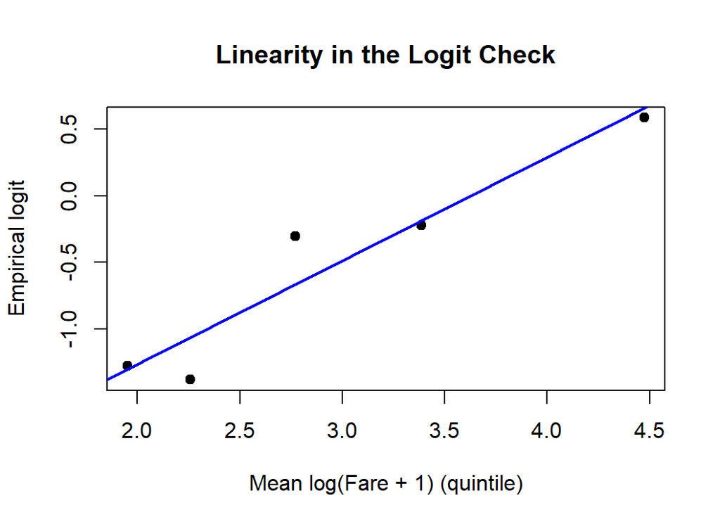

```r
plot(quint$mean.logfare, quint$emp.logit, pch = 19,
     xlab = "Mean log(Fare + 1) (quintile)", ylab = "Empirical logit",
     main = "Linearity in the Logit Check")
abline(b0, b1, col = "blue", lwd = 2)
```

**Influential observations.**

```r
cd <- cooks.distance(s.logit)
c(max.cooks.d = max(cd), obs = which.max(cd), fare = titanic$fare[which.max(cd)])
```

```
 max.cooks.d      obs.272         fare
  0.03143383 272.00000000   0.00000000
```

The area under the ROC curve (computed through the Mann-Whitney relationship) shows how well the fitted probabilities separate survivors from non-survivors:

```r
ph <- fitted(s.logit)
auc <- (sum(rank(ph)[titanic$survived == 1]) - n.surv * (n.surv + 1) / 2) / (n.surv * n.died)
auc
```

```
[1] 0.6921223
```

```r
pred <- factor(as.numeric(ph >= 0.5), levels = c(0, 1))
table(Observed = titanic$survived, Predicted = pred)
```

```
        Predicted
Observed   0   1
       0 475  74
       1 222 120
```

An AUC of **0.692** is modest, so fare alone separates survivors from non-survivors to a limited degree. Only about 38% survived, the 0.5 cutoff predicts “died” for most passengers. A different cutoff or additional predictors would be needed before using this model for classification.

# 7 Conclusion and Discussion

This case study explores the relationship between survival on the *Titanic* and the fare paid. Because fare is extremely right-skewed, the predictor was log-transformed, which also gave a much better fit than the raw fare. The results show a positive association with the odds of survival multiplied by about 1.71 each time the fare doubles (95% CI [1.53, 1.92]. Wald *z* = 9.3, *p* <.0001). The effect on the probability scale is not constant. It is strongest at low fares and levels off for expensive tickets. The model’s explanatory power is limited (McFadden $R^2$ = 0.086, AUC = 0.692), which makes sense because the development of survival odds involves many factors and fare is probably standing in for passenger class, sex, or age. The analysis could be improved by incorporating additional variables.